# Group_Work_Project_1,_group_8072

## Introduction

In the realm of financial data analysis, ensuring the quality and reliability of data is paramount. The significance of good quality data becomes evident when we examine its implications in financial modeling and decision-making processes. This assignment is structured to provide a comprehensive understanding of data quality, yield curve modeling, the exploitation of correlation, and empirical analysis of Exchange-Traded Funds (ETFs), all within the broader context of financial data analysis.

Firstly (Question 1), we will delve into the concept of data quality by providing examples of poor-quality structured and unstructured data, along with methods to identify their shortcomings. This foundational knowledge is crucial for recognizing the importance of maintaining high standards in financial data.

Furthermore, in Question 3 we will investigate the role of correlation and principal components in financial data analysis by generating uncorrelated Gaussian random variables and running Principal Component Analysis (PCA). The analysis will be extended to real data, collecting daily closing yields for government securities and comparing the results through screeplots.

Lastly, in Question 4, the empirical analysis of ETFs will involve computing daily returns, covariance matrices, PCA, and Singular Value Decomposition (SVD) for a sector ETF, providing a thorough explanation of each transformation and its implications.

## Installing Packages

```python
! pip install -q kaggle --quiet
! pip install pandas  --quiet
! pip install numpy  --quiet
! pip install matplotlib --quiet
! pip install seaborn --quiet
! pip install pingouin --quiet
! pip install factor_analyzer --quiet
! pip install gdown --quiet
! pip install datetime --quiet
! pip install requests --quiet
! pip install yfinance --quiet
! pip install pandas-datareader --quiet
```

```
   ━━━━━━━━━━━━━━━━━━━━━━━━━━━━━━━━━━━━━━━━ 204.4/204.4 kB 5.5 MB/s eta 0:00:00
     ━━━━━━━━━━━━━━━━━━━━━━━━━━━━━━━━━━━━━━━━ 42.8/42.8 kB 2.0 MB/s eta 0:00:00
  Installing build dependencies ... done
  Getting requirements to build wheel ... done
  Preparing metadata (pyproject.toml) ... done
     ━━━━━━━━━━━━━━━━━━━━━━━━━━━━━━━━━━━━━━━━ 44.4/44.4 kB 2.1 MB/s eta 0:00:00
   ━━━━━━━━━━━━━━━━━━━━━━━━━━━━━━━━━━━━━━━━ 52.6/52.6 kB 4.1 MB/s eta 0:00:00
   ━━━━━━━━━━━━━━━━━━━━━━━━━━━━━━━━━━━━━━━━ 259.8/259.8 kB 10.2 MB/s eta 0:00:00
```

## Importing packages

```python
import pandas as pd
from factor_analyzer import FactorAnalyzer
from factor_analyzer.factor_analyzer import calculate_bartlett_sphericity
from factor_analyzer.factor_analyzer import calculate_kmo
import pingouin as pg
import seaborn as sns
import numpy as np
import matplotlib.pyplot as plt
from numpy import linalg as LA
from scipy.interpolate import CubicSpline
from scipy.optimize import minimize
from datetime import datetime, timedelta
import time
from operator import index
import yfinance as yfin
from PIL.ImageChops import screen
from fontTools.misc.plistlib import end_key
from matplotlib.projections import projection_registry
from numpy.array_api import full_like
from numpy.core.shape_base import block
from numpy.ma.core import around, outer
from rich.jupyter import display
from scipy import stats
from numpy import linalg as la
from scipy.odr import exponential
from unicodedata import decimal
from IPython.display import set_matplotlib_formats
import math
import re
import gdown
import warnings
import requests
warnings.filterwarnings('ignore')
```

## **Question 1: Data Quality**

### a. Provide an example of poor quality structured data

**Answer**

```python
file_id = "1Rp1Ubva5Q7ReW_zs7EowH3yge8rq-i5w"
url = f"https://drive.google.com/uc?id={file_id}"
output_filename = "financials.zip"
gdown.download(url, output_filename, quiet=False)

import os
if os.path.exists(output_filename):
    print(f"File '{output_filename}' downloaded successfully!")
else:
    print("File download failed.")
try:
    import pandas as pd
    datafin = pd.read_csv(output_filename)
#    print(datafin.head())
except Exception as e:
    print(f"Unable to read the file: {e}")

datafin.head()
```

```
Downloading...
From: https://drive.google.com/uc?id=1Rp1Ubva5Q7ReW_zs7EowH3yge8rq-i5w
To: /content/financials.zip
```

```
File 'financials.zip' downloaded successfully!
```

|  | Segment | Country | Product | Discount Band | Units Sold | Manufacturing Price | Sale Price | Gross Sales | Discounts | Sales | COGS | Profit | Date | Month Number | Month Name | Year |
| --- | --- | --- | --- | --- | --- | --- | --- | --- | --- | --- | --- | --- | --- | --- | --- | --- |
| 0 | Government | Canada | Carretera | None | $1,618.50 | $3.00 | $20.00 | $32,370.00 | $- | $32,370.00 | $16,185.00 | $16,185.00 | 01/01/2014 | 1 | January | 2014 |
| 1 | Government | Germany | Carretera | None | $1,321.00 | $3.00 | $20.00 | $26,420.00 | $- | $26,420.00 | $13,210.00 | $13,210.00 | 01/01/2014 | 1 | January | 2014 |
| 2 | Midmarket | France | Carretera | None | $2,178.00 | $3.00 | $15.00 | $32,670.00 | $- | $32,670.00 | $21,780.00 | $10,890.00 | 01/06/2014 | 6 | June | 2014 |
| 3 | Midmarket | Germany | Carretera | None | $888.00 | $3.00 | $15.00 | $13,320.00 | $- | $13,320.00 | $8,880.00 | $4,440.00 | 01/06/2014 | 6 | June | 2014 |
| 4 | Midmarket | Mexico | Carretera | None | $2,470.00 | $3.00 | $15.00 | $37,050.00 | $- | $37,050.00 | $24,700.00 | $12,350.00 | 01/06/2014 | 6 | June | 2014 |

```python
datafin.info()
```

```
<class 'pandas.core.frame.DataFrame'>
RangeIndex: 700 entries, 0 to 699
Data columns (total 16 columns):
 #   Column                 Non-Null Count  Dtype
---  ------                 --------------  -----
 0   Segment                700 non-null    object
 1   Country                700 non-null    object
 2    Product               700 non-null    object
 3    Discount Band         700 non-null    object
 4    Units Sold            700 non-null    object
 5    Manufacturing Price   700 non-null    object
 6    Sale Price            700 non-null    object
 7    Gross Sales           700 non-null    object
 8    Discounts             700 non-null    object
 9     Sales                700 non-null    object
 10   COGS                  700 non-null    object
 11   Profit                700 non-null    object
 12  Date                   700 non-null    object
 13  Month Number           700 non-null    int64
 14   Month Name            700 non-null    object
 15  Year                   700 non-null    int64
dtypes: int64(2), object(14)
memory usage: 87.6+ KB
```

**Data description:** This dataset, sourced from [Atharva Arya](https://www.kaggle.com/datasets/atharvaarya25/financials), provides detailed sales and profit information across various market segments and countries, including key metrics like units sold, sale price, gross sales, discounts, and profit. It enables in-depth analysis of sales performance, profitability, and time-based trends to support business insights and decision-making.

```python
datafin.head()
```

|  | Segment | Country | Product | Discount Band | Units Sold | Manufacturing Price | Sale Price | Gross Sales | Discounts | Sales | COGS | Profit | Date | Month Number | Month Name | Year |
| --- | --- | --- | --- | --- | --- | --- | --- | --- | --- | --- | --- | --- | --- | --- | --- | --- |
| 0 | Government | Canada | Carretera | None | $1,618.50 | $3.00 | $20.00 | $32,370.00 | $- | $32,370.00 | $16,185.00 | $16,185.00 | 01/01/2014 | 1 | January | 2014 |
| 1 | Government | Germany | Carretera | None | $1,321.00 | $3.00 | $20.00 | $26,420.00 | $- | $26,420.00 | $13,210.00 | $13,210.00 | 01/01/2014 | 1 | January | 2014 |
| 2 | Midmarket | France | Carretera | None | $2,178.00 | $3.00 | $15.00 | $32,670.00 | $- | $32,670.00 | $21,780.00 | $10,890.00 | 01/06/2014 | 6 | June | 2014 |
| 3 | Midmarket | Germany | Carretera | None | $888.00 | $3.00 | $15.00 | $13,320.00 | $- | $13,320.00 | $8,880.00 | $4,440.00 | 01/06/2014 | 6 | June | 2014 |
| 4 | Midmarket | Mexico | Carretera | None | $2,470.00 | $3.00 | $15.00 | $37,050.00 | $- | $37,050.00 | $24,700.00 | $12,350.00 | 01/06/2014 | 6 | June | 2014 |

```python
# Checking if there are any NA values
datafin.isna().any().any()
```

```
False
```

```python
# Checking if there are duplicated data
datafin.duplicated().sum()
```

```
0
```

```python
datafin[' Discount Band '].unique()
```

```
array([' None ', ' Low ', ' Medium ', ' High '], dtype=object)
```

```python
datafin.columns
```

```
Index(['Segment', 'Country', ' Product ', ' Discount Band ', ' Units Sold ',
       ' Manufacturing Price ', ' Sale Price ', ' Gross Sales ', ' Discounts ',
       '  Sales ', ' COGS ', ' Profit ', 'Date', 'Month Number',
       ' Month Name ', 'Year'],
      dtype='object')
```

### b. How would you recognize this poor quality?

Write 3 - 4 sentences that show how the data fails to include properties of good quality data.

**Answer**

Although the data does not have missing or duplicated values, it includes currency symbols ($), missing or incorrect values, like the placeholder ($-), commas, and extra spaces before and after the names of some variables as well as their observations. Additionally, quantitative variables are classified as objects rather than as integers (int) or floats, which makes it difficult to perform numerical operations or analysis.

c. Provide an example of poor quality unstructured data

```python
file_id = "1NIakNIwqoDgw9CvFWrU-s-uuJHdu6KQu"
url = f"https://drive.google.com/uc?id={file_id}"
output_filename = "Airplane_Crashes_and_Fatalities_Since_1908.csv.zip"
gdown.download(url, output_filename, quiet=False)

import os
if os.path.exists(output_filename):
    print(f"File '{output_filename}' downloaded successfully!")
else:
    print("File download failed.")

try:
    import pandas as pd
    data = pd.read_csv(output_filename)
  #  print(data.head())
except Exception as e:
    print(f"Unable to read the file: {e}")
data.head()
```

```
Downloading...
From: https://drive.google.com/uc?id=1NIakNIwqoDgw9CvFWrU-s-uuJHdu6KQu
To: /content/Airplane_Crashes_and_Fatalities_Since_1908.csv.zip
```

```
File 'Airplane_Crashes_and_Fatalities_Since_1908.csv.zip' downloaded successfully!
```

|  | index | Date | Time | Location | Operator | Flight # | Route | Type | Registration | cn/In | Aboard | Fatalities | Ground | Summary |
| --- | --- | --- | --- | --- | --- | --- | --- | --- | --- | --- | --- | --- | --- | --- |
| 0 | 0 | 09/17/1908 | 17:18 | Fort Myer, Virginia | Military - U.S. Army | NaN | Demonstration | Wright Flyer III | NaN | 1 | 2.0 | 1.0 | 0.0 | During a demonstration flight, a U.S. Army fly... |
| 1 | 1 | 07/12/1912 | 06:30 | AtlantiCity, New Jersey | Military - U.S. Navy | NaN | Test flight | Dirigible | NaN | NaN | 5.0 | 5.0 | 0.0 | First U.S. dirigible Akron exploded just offsh... |
| 2 | 2 | 08/06/1913 | NaN | Victoria, British Columbia, Canada | Private | - | NaN | Curtiss seaplane | NaN | NaN | 1.0 | 1.0 | 0.0 | The first fatal airplane accident in Canada oc... |
| 3 | 3 | 09/09/1913 | 18:30 | Over the North Sea | Military - German Navy | NaN | NaN | Zeppelin L-1 (airship) | NaN | NaN | 20.0 | 14.0 | 0.0 | The airship flew into a thunderstorm and encou... |
| 4 | 4 | 10/17/1913 | 10:30 | Near Johannisthal, Germany | Military - German Navy | NaN | NaN | Zeppelin L-2 (airship) | NaN | NaN | 30.0 | 30.0 | 0.0 | Hydrogen gas which was being vented was sucked... |

```python
data.info()
```

```
<class 'pandas.core.frame.DataFrame'>
RangeIndex: 5268 entries, 0 to 5267
Data columns (total 14 columns):
 #   Column        Non-Null Count  Dtype
---  ------        --------------  -----
 0   index         5268 non-null   int64
 1   Date          5268 non-null   object
 2   Time          3049 non-null   object
 3   Location      5248 non-null   object
 4   Operator      5250 non-null   object
 5   Flight #      1069 non-null   object
 6   Route         3561 non-null   object
 7   Type          5241 non-null   object
 8   Registration  4933 non-null   object
 9   cn/In         4040 non-null   object
 10  Aboard        5246 non-null   float64
 11  Fatalities    5256 non-null   float64
 12  Ground        5246 non-null   float64
 13  Summary       4878 non-null   object
dtypes: float64(3), int64(1), object(10)
memory usage: 576.3+ KB
```

```python
data.columns
```

```
Index(['index', 'Date', 'Time', 'Location', 'Operator', 'Flight #', 'Route',
       'Type', 'Registration', 'cn/In', 'Aboard', 'Fatalities', 'Ground',
       'Summary'],
      dtype='object')
```

```python
data.isna().sum()
```

|  | 0 |
| --- | --- |
| index | 0 |
| Date | 0 |
| Time | 2219 |
| Location | 20 |
| Operator | 18 |
| Flight # | 4199 |
| Route | 1707 |
| Type | 27 |
| Registration | 335 |
| cn/In | 1228 |
| Aboard | 22 |
| Fatalities | 12 |
| Ground | 22 |
| Summary | 390 |

**dtype:** int64

```python
data.duplicated().sum()
```

```
0
```

```python
groupdata = data.groupby(['Date', 'Time', 'Location', 'Flight #'])['Fatalities'].sum()
groupdata
```

| Date | Time | Location | Flight # | Fatalities |
| --- | --- | --- | --- | --- |
| 01/01/1976 | 05:30 | Near Al Qaysumah, Saudi Arabia | 438 | 82.0 |
| 01/01/1978 | 20:15 | Off Bandra, Maharashtra, India | 855 | 213.0 |
| 01/01/1985 | 20:30 | Near La Paz, Bolivia | 980 | 29.0 |
| 01/01/2002 | 18:02 | Hollywood, Florida | - | 5.0 |
| 01/01/2007 | 14:07 | Off Parepare, Indonesia | 574 | 102.0 |
| ... | ... | ... | ... | ... |
| 12/29/1991 | 15:05 | Wanli, Taiwan | 358 | 5.0 |
| 12/29/1994 | 15:30 | Near Van, Turkey | 278 | 57.0 |
| 12/30/1945 | 21:13 | New York City, New York | 14 | 1.0 |
| 12/30/1951 | 22:07 | Near Fairbanks, Alaska | 501 | 4.0 |
| 12/31/1968 | 08:30 | Port Hedland, WA, Australia | 1750 | 26.0 |

996 rows × 1 columns

**dtype:** float64

```python
filtered_data=data[(data['Time'].isna() & data['Flight #'].isna()) & (data['Fatalities'] >= 10)]
filtered_data.head()
```

|  | index | Date | Time | Location | Operator | Flight # | Route | Type | Registration | cn/In | Aboard | Fatalities | Ground | Summary |
| --- | --- | --- | --- | --- | --- | --- | --- | --- | --- | --- | --- | --- | --- | --- |
| 7 | 7 | 07/28/1916 | NaN | Near Jambol, Bulgeria | Military - German Army | NaN | NaN | Schutte-Lanz S-L-10 (airship) | NaN | NaN | 20.0 | 20.0 | 0.0 | Crashed near the Black Sea, cause unknown. |
| 10 | 10 | 11/21/1916 | NaN | Mainz, Germany | Military - German Army | NaN | NaN | Super Zeppelin (airship) | NaN | NaN | 28.0 | 27.0 | 0.0 | Crashed in a storm. |
| 12 | 12 | 03/04/1917 | NaN | Near Gent, Belgium | Military - German Army | NaN | NaN | Airship | NaN | NaN | 20.0 | 20.0 | 0.0 | Caught fire and crashed. |
| 13 | 13 | 03/30/1917 | NaN | Off Northern Germany | Military - German Navy | NaN | NaN | Schutte-Lanz S-L-9 (airship) | NaN | NaN | 23.0 | 23.0 | 0.0 | Struck by lightning and crashed into the Balti... |
| 19 | 19 | 05/10/1918 | NaN | Off Helgoland Island, Germany | Military - German Navy | NaN | NaN | Zeppelin L-70 (airship) | NaN | NaN | 22.0 | 22.0 | 0.0 | Shot down by British aircraft crashing from a ... |

```python
filtered_data.shape
```

```
(986, 14)
```

d. Unstructured data can be more difficult to assess than structured data. Just you did in part b, write 3 - 4 sentences that show how this unstructured data fails to check requirements of good quality data.

**Answer**

## **Question 2: Yield Curve Modeling**

a. Pick government securities from a country. The country selected should be one of the countries from your group so that you can fit a Nelson-Siegel mode

**Answer**

Fitting a Nelson-Siegel model on EU government securities

```python
base_url = 'https://sdw-wsrest.ecb.europa.eu/service/'
params = {
   'startPeriod': '2020-01-01',
   'endPeriod': '2024-12-31',
   'format': 'jsondata'
}

maturities = ['SR_3M', 'SR_1Y', 'SR_2Y', 'SR_5Y', 'SR_10Y', 'SR_30Y']
data_dict = {}

for maturity in maturities:
   url = f"{base_url}data/YC/B.U2.EUR.4F.G_N_A.SV_C_YM.{maturity}"
   response = requests.get(url, params=params)
   data = response.json()

   # Extract values (first element of each observation array)
   values = [obs[0] for obs in data['dataSets'][0]['series']['0:0:0:0:0:0:0']['observations'].values()]

   # Get dates from structure
   dates = [date['id'] for date in data['structure']['dimensions']['observation'][0]['values']]

   data_dict[maturity] = pd.Series(values, index=pd.to_datetime(dates))

df = pd.DataFrame(data_dict)
df.columns = ['3M', '1Y', '2Y', '5Y', '10Y', '30Y']
```

b. Be sure to pick maturities ranging from short-term to long-term (e.g. 6 month maturity to 20 or 30 year maturities).

**Answer**

```python
df
```

|  | 3M | 1Y | 2Y | 5Y | 10Y | 30Y |
| --- | --- | --- | --- | --- | --- | --- |
| 2020-01-02 | -0.623324 | -0.634844 | -0.622180 | -0.478606 | -0.173995 | 0.358465 |
| 2020-01-03 | -0.595449 | -0.630324 | -0.638365 | -0.520394 | -0.222926 | 0.306064 |
| 2020-01-06 | -0.597296 | -0.637580 | -0.651086 | -0.541757 | -0.247426 | 0.283818 |
| 2020-01-07 | -0.605300 | -0.641443 | -0.650553 | -0.532864 | -0.232130 | 0.304965 |
| 2020-01-08 | -0.597340 | -0.633612 | -0.641188 | -0.515378 | -0.204580 | 0.341047 |
| ... | ... | ... | ... | ... | ... | ... |
| 2024-12-20 | 2.616587 | 2.172129 | 1.960729 | 2.049615 | 2.374684 | 2.445430 |
| 2024-12-23 | 2.632250 | 2.201549 | 1.997799 | 2.084822 | 2.402344 | 2.456214 |
| 2024-12-24 | 2.661780 | 2.211694 | 2.003148 | 2.090155 | 2.405459 | 2.455847 |
| 2024-12-27 | 2.653268 | 2.188540 | 2.007697 | 2.126310 | 2.431800 | 2.494656 |
| 2024-12-30 | 2.575177 | 2.178646 | 2.011151 | 2.130018 | 2.447304 | 2.513773 |

1278 rows × 6 columns

```python
df.to_csv('yield_curves.csv')
```

```python
def nelson_siegel(t, params):
    beta0, beta1, beta2, tau = params
    # Avoid division by zero
    exp_term = np.exp(-t/tau)
    term = (1 - exp_term)/(t/tau)
    return beta0 + beta1 * term + beta2 * (term - exp_term)

def objective(params, t, y):
    return np.sum((nelson_siegel(t, params) - y)**2)

# Convert maturities to years
maturities = np.array([0.25, 1, 2, 5, 10, 30])

# Fit for each date
results = []
for date in df.index:
    yields = df.loc[date].values

    # Initial parameters [β₀, β₁, β₂, τ]
    initial_guess = [yields[-1], yields[0]-yields[-1], 0, 2]

    # Bounds for parameters
    bounds = [(0, 15), (-15, 15), (-15, 15), (0.1, 10)]

    res = minimize(objective, initial_guess, args=(maturities, yields),
                  bounds=bounds, method='L-BFGS-B')

    # Store parameters and fitted yields
    params = res.x
    fitted_yields = nelson_siegel(maturities, params)
    rmse = np.sqrt(np.mean((yields - fitted_yields)**2))

    results.append({
        'date': date,
        'beta0': params[0],  # Level
        'beta1': params[1],  # Slope
        'beta2': params[2],  # Curvature
        'tau': params[3],    # Decay
        'rmse': rmse
    })

# Create DataFrame of results
results_df = pd.DataFrame(results).set_index('date')
```

```python
results_df
```

| date | beta0 | beta1 | beta2 | tau | rmse |
| --- | --- | --- | --- | --- | --- |
| 2020-01-02 | 0.698999 | -1.310728 | -1.646603 | 3.455619 | 0.001258 |
| 2020-01-03 | 0.640179 | -1.215057 | -1.799441 | 3.325815 | 0.000900 |
| 2020-01-06 | 0.620464 | -1.195045 | -1.839001 | 3.329411 | 0.000919 |
| 2020-01-07 | 0.644782 | -1.228894 | -1.830838 | 3.332548 | 0.000943 |
| 2020-01-08 | 0.683263 | -1.259286 | -1.862525 | 3.289445 | 0.000826 |
| ... | ... | ... | ... | ... | ... |
| 2024-12-20 | 2.569276 | 0.315362 | -2.540065 | 1.188862 | 0.035549 |
| 2024-12-23 | 2.576592 | 0.318141 | -2.435052 | 1.169326 | 0.037266 |
| 2024-12-24 | 2.575070 | 0.360573 | -2.474106 | 1.149855 | 0.037276 |
| 2024-12-27 | 2.607960 | 0.329663 | -2.519298 | 1.095611 | 0.032313 |
| 2024-12-30 | 2.632903 | 0.187122 | -2.373655 | 1.157329 | 0.034248 |

1278 rows × 5 columns

c. Fit a Nelson-Siegel model.

**Answer**

```
Fitted Parameters:
β0 (level): 2.0494
β1 (slope): -0.3579
β2 (curvature): 1.3981
τ (decay): 0.2822
```

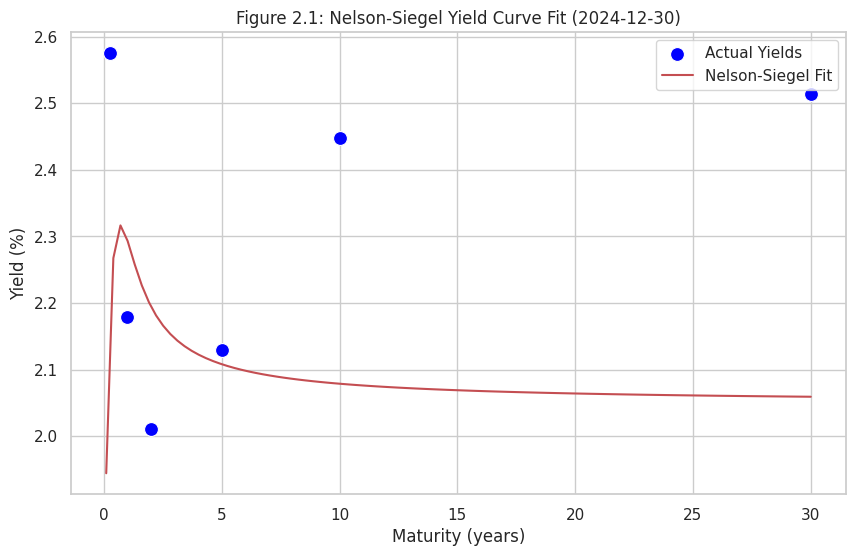

```python
sns.set()

# Read data
df = pd.read_csv('yield_curves.csv', index_col=0)
df.index = pd.to_datetime(df.index)

# Nelson-Siegel function
def nelson_siegel(t, params):
    beta0, beta1, beta2, tau = params
    exp_term = np.exp(-t/tau)
    return beta0 + beta1 * ((1 - exp_term)/(t/tau)) + beta2 * ((1 - exp_term)/(t/tau) - exp_term)

# Objective function
def objective(params, maturities, rates):
    return np.sum((nelson_siegel(maturities, params) - rates)**2)

# Convert maturities to years
maturities = np.array([0.25, 1, 2, 5, 10, 30])
latest_rates = df.iloc[-1].values

# Fit Nelson-Siegel model
initial_guess = [3, -2, 2, 1]  # [beta0, beta1, beta2, tau]
result = minimize(objective, initial_guess, args=(maturities, latest_rates))
fitted_params = result.x

# Generate smooth curve
t_points = np.linspace(0.1, 30, 100)
fitted_curve = nelson_siegel(t_points, fitted_params)

# Plot
plt.figure(figsize=(10, 6))
sns.set_style('whitegrid')
sns.scatterplot(x=maturities, y=latest_rates, color='blue', s=100, label='Actual Yields')
plt.plot(t_points, fitted_curve, 'r-', label='Nelson-Siegel Fit')
plt.xlabel('Maturity (years)')
plt.ylabel('Yield (%)')
plt.title(f'Figure 2.1: Nelson-Siegel Yield Curve Fit ({df.index[-1].strftime("%Y-%m-%d")})')
plt.legend()
plt.grid(True)

print("Fitted Parameters:")
print(f"β0 (level): {fitted_params[0]:.4f}")
print(f"β1 (slope): {fitted_params[1]:.4f}")
print(f"β2 (curvature): {fitted_params[2]:.4f}")
print(f"τ (decay): {fitted_params[3]:.4f}")

plt.show()
```

d. Fit a Cubic-Spline model.

**Answer**

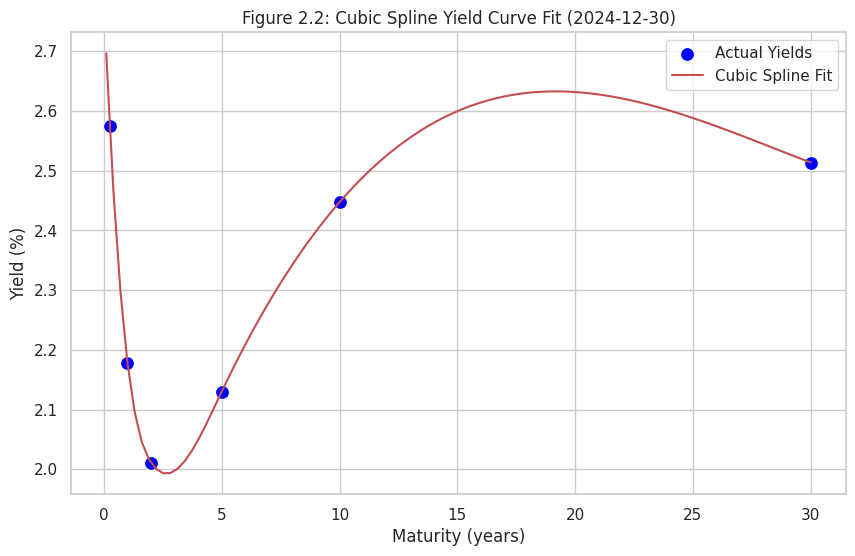

```python
cs = CubicSpline(maturities, latest_rates)

# Generate smooth curve
t_points = np.linspace(0.1, 30, 100)
fitted_curve = cs(t_points)

# Plot
plt.figure(figsize=(10, 6))
sns.set_style('whitegrid')
sns.scatterplot(x=maturities, y=latest_rates, color='blue', s=100, label='Actual Yields')
plt.plot(t_points, fitted_curve, 'r-', label='Cubic Spline Fit')
plt.xlabel('Maturity (years)')
plt.ylabel('Yield (%)')
plt.title(f'Figure 2.2: Cubic Spline Yield Curve Fit ({df.index[-1].strftime("%Y-%m-%d")})')
plt.legend()
plt.grid(True)
plt.show()
```

e. Compare the models in terms of 1) fit and 2) interpretation

**Answer**

f. Be sure to specify at the levels of model parameters (ex. Alpha1).

**Answer**

g. In Module 2 Lesson 4 (‘Smoothing Data’), we said smoothing data can be unethical. If Nelson-Siegel is smoothing the yield curve, is this considered unethical? Why or why not?

**Answer**

Using smoothing techniques like the Nelson-Siegel method to estimate yield curves is typically ethical when the goal is to improve the accuracy of models and better understand market trends. These methods help to remove noise and clarify long-term data patterns. However, it crosses into unethical territory if used to mislead stakeholders or distort data, such as by inflating asset values or hiding volatility. The key to ethical use lies in being transparent about the methodology and intentions. Problems arise when the smoothing process is used to misrepresent the true nature of the data (Copeland 103).

## **3. Exploiting Correlation**

Financial Data is meant not only to process data but to understand how meaningful factors can be used to summarize or represent the data. Let’s understand the role that correlation and principal components play.

a) Generate 5 uncorrelated Gaussian random variables that simulate yield changes (they can be positive or negative with a mean close to 0 and a standard deviation that is small).

### **Answer**

Table of first five values generated

```python
np.random.seed(432)
num_samples = 100
num_variables = 5
mean=0
std_deviation=0.01
data=np.random.normal(loc=mean,scale=std_deviation, size=(num_samples,num_variables))
dataF=pd.DataFrame(data)
dataF.columns=["Variable 1","Variable 2","Variable 3","Variable 4","Variable 5"]
dataF.head()
```

|  | Variable 1 | Variable 2 | Variable 3 | Variable 4 | Variable 5 |
| --- | --- | --- | --- | --- | --- |
| 0 | 0.001869 | 0.000345 | -0.003848 | 0.004646 | 0.006009 |
| 1 | -0.017359 | -0.003120 | 0.003078 | -0.002261 | -0.000731 |
| 2 | 0.000010 | 0.003327 | 0.019509 | -0.007947 | 0.006518 |
| 3 | -0.000422 | -0.003114 | 0.000570 | 0.003264 | -0.003010 |
| 4 | 0.002769 | 0.005642 | 0.005877 | 0.016587 | -0.014441 |

**Correlation matrix**

```python
matrix_corr = dataF.corr()
print(matrix_corr)
```

```
            Variable 1  Variable 2  Variable 3  Variable 4  Variable 5
Variable 1    1.000000   -0.008919    0.039846    0.013316    0.202243
Variable 2   -0.008919    1.000000    0.121684    0.155779   -0.133540
Variable 3    0.039846    0.121684    1.000000   -0.130289   -0.111868
Variable 4    0.013316    0.155779   -0.130289    1.000000   -0.092115
Variable 5    0.202243   -0.133540   -0.111868   -0.092115    1.000000
```

**Correloplot**

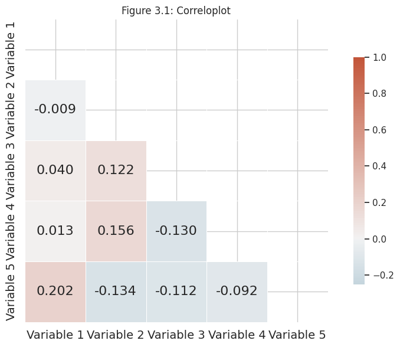

```python
corr = dataF.corr()

f, ax =plt.subplots(figsize=(9, 6))
mask=np.triu(np.ones_like(corr, dtype=bool))
cmap=sns.diverging_palette(230, 20, n=256, as_cmap=True)
sns.heatmap(dataF.corr(),
            mask=mask,
            cmap=cmap,
            vmax=1,
            vmin = -.25,
            center=0,
            square=True,
            linewidths=.5,
            annot = True,
            fmt='.3f',
            annot_kws={'size': 16},
            cbar_kws={"shrink": .75})

plt.title('Figure 3.1: Correloplot')
plt.tight_layout()
ax.tick_params(axis = 'x', labelsize = 14)
ax.tick_params(axis = 'y', labelsize = 14)
ax.set_ylim(len(corr))

plt.show()
```

As we see in the correleplot (Figure 3.1) all correlation values a near zero, which aline to what exercise need, 5 uncorrelated exercises.

b) Run a Principal Components using EITHER the correlation OR covariance matrix.

**Answer**

Eigenvalues

```python
# Calculating eigenvectors and eigenvalues of the covariance matrix of simulated dataset
dataF_cov = dataF.cov()
eigenvalues, eigenvectors = LA.eig(dataF_cov)
sorted_indices=np.argsort(eigenvalues)[::-1]
eigenvectors=eigenvectors[:,sorted_indices]
eigenvalues=eigenvalues[sorted_indices]
eigenvalues
```

```
array([1.27782260e-04, 1.14523588e-04, 9.47725977e-05, 7.27875167e-05,
       6.21821048e-05])
```

**Eigenvectors**

```python
eigenvectors
```

```
array([[ 0.1038149 , -0.21881596, -0.68515343, -0.26798617, -0.63252686],
       [-0.49630891,  0.41260863, -0.40928584,  0.64272115, -0.053162  ],
       [-0.74956086, -0.50816345, -0.1023671 , -0.29393446,  0.28818733],
       [-0.01974409,  0.64348683, -0.31144041, -0.59654411,  0.3642456 ],
       [ 0.42505132, -0.33101102, -0.50554497,  0.26987143,  0.61754091]])
```

**Principal components**

```python
principal_components =dataF.dot(eigenvectors)
principal_components.columns = ["PC_1","PC_2","PC_3","PC_4","PC_5"]
principal_components.head()
```

|  | PC_1 | PC_2 | PC_3 | PC_4 | PC_5 |
| --- | --- | --- | --- | --- | --- |
| 0 | 0.005369 | 0.002689 | -0.005512 | -0.000298 | 0.003094 |
| 1 | -0.002826 | -0.000266 | 0.013929 | 0.002893 | 0.010758 |
| 2 | -0.013346 | -0.015815 | -0.004186 | 0.002901 | 0.006569 |
| 3 | -0.000269 | 0.001614 | 0.002010 | -0.004816 | -0.000073 |
| 4 | -0.013384 | 0.014189 | -0.002674 | -0.012635 | -0.003234 |

c) Write a paragraph explaining how the variances of each component compare with each other. In this paragraph, you will address the following question: how much variance is explained by Component 1, Component 2, Component 3?

**Answer**

```python
# Put data into a DataFrame
df_eigval = pd.DataFrame({"Eigenvalues":eigenvalues}, index=range(1,6))

# Work out explained proportion
df_eigval["Explained variance proportion"] = df_eigval["Eigenvalues"] / np.sum(df_eigval["Eigenvalues"])
df_eigval["Cumulative variance proportion"] = df_eigval["Explained variance proportion"].cumsum()
#Format as percentage
df_eigval.style.format({"Explained variance proportion": "{:.2%}",
    "Cumulative variance proportion": "{:.2%}"})
```

|  | Eigenvalues | Explained variance proportion | Cumulative variance proportion |
| --- | --- | --- | --- |
| 1 | 0.000128 | 27.07% | 27.07% |
| 2 | 0.000115 | 24.26% | 51.33% |
| 3 | 0.000095 | 20.08% | 71.41% |
| 4 | 0.000073 | 15.42% | 86.83% |
| 5 | 0.000062 | 13.17% | 100.00% |

The component 1, component 2 and component 3 explain 27.07%, 24.26% and 20.08%, respectively, of the total variability of our dataset. Cumulatively, the first three components explain 71.41% of the total data variability.

d. Produce a screeplot (see https://en.wikipedia.org/wiki/Scree_plot) of the variance explained for each component.

**Answer**

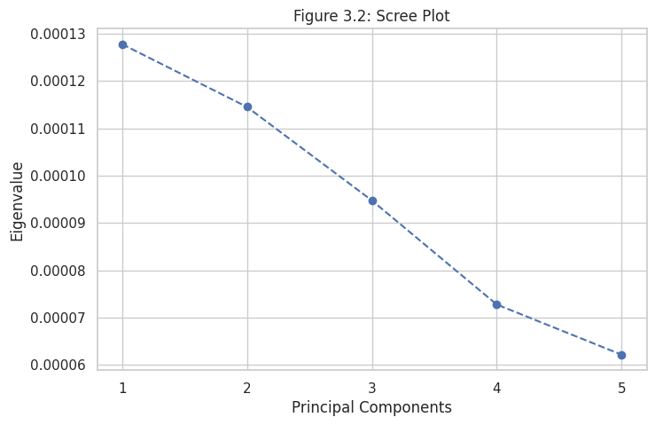

```python
plt.figure(figsize=(8, 5))
plt.plot(range(1,len(eigenvalues)+1), eigenvalues, marker="o",linestyle="--")
plt.title("Figure 3.2: Scree Plot")
plt.xlabel("Principal Components")
plt.ylabel("Eigenvalue")
plt.xticks(range(1,len(eigenvalues)+1))
plt.grid(True)
```

e. Collect the daily closing yields for 5 government securities, say over 6 months.

**Answer**

```python
api_key = "ec67a401ae513935b544843d8c308536"  # Alex API
series_ids = [
    'DGS1',
    'DGS2',
    'DGS5',
    'DGS10',
    'DGS30'
]

base_url = "https://api.stlouisfed.org/fred/series/observations"

# Date range for the past 7 months
end_date = datetime.now().date()
start_date = end_date - timedelta(days=7*30)  # 7 months ago

# Function to fetch yield data
def get_yield_data(series_id, start_date, end_date):
    params = {
        "series_id": series_id,
        "api_key": api_key,
        "file_type": "json",
        "observation_start": str(start_date),
        "observation_end": str(end_date),
    }

    response = requests.get(base_url, params=params)
    if response.status_code == 200:
        res_data = response.json()
        if 'observations' in res_data:
            obs_data = pd.DataFrame(res_data['observations'])
            obs_data['date'] = pd.to_datetime(obs_data['date'])
            obs_data.set_index('date', inplace=True)
            obs_data['value'] = pd.to_numeric(obs_data['value'], errors='coerce')
            return obs_data
    return None

# Collect yield data for each series
yields_dict = {}
for series_id in series_ids:
    yields_dict[series_id] = get_yield_data(series_id, start_date, end_date)

# Combine data into a single DataFrame
yields_df = pd.DataFrame({series_id: data['value'] for series_id, data in yields_dict.items() if data is not None})
yields_df.columns = ['1 Year', '2 Year', '5 Year', '10 Year', '30 Year']
# Compute daily yield changes using .diff()
daily_yield_changes = yields_df.diff()
daily_yield_changes.dropna(inplace=True)
print(daily_yield_changes)
```

```
            1 Year  2 Year  5 Year  10 Year  30 Year
date
2024-06-25    0.00   -0.06   -0.02    -0.02    -0.02
2024-06-26    0.03    0.06    0.07     0.09     0.09
2024-06-27   -0.03   -0.01   -0.03    -0.03    -0.02
2024-06-28   -0.01    0.01    0.04     0.07     0.08
2024-07-01    0.01    0.06    0.11     0.12     0.13
...            ...     ...     ...      ...      ...
2025-01-10    0.09    0.13    0.13     0.09     0.04
2025-01-13   -0.01    0.00    0.02     0.02     0.01
2025-01-14   -0.02   -0.03   -0.02    -0.01     0.01
2025-01-15   -0.03   -0.10   -0.14    -0.12    -0.10
2025-01-16   -0.01   -0.04   -0.06    -0.05    -0.04

[134 rows x 5 columns]
```

f. Be sure to compute the daily yield changes!

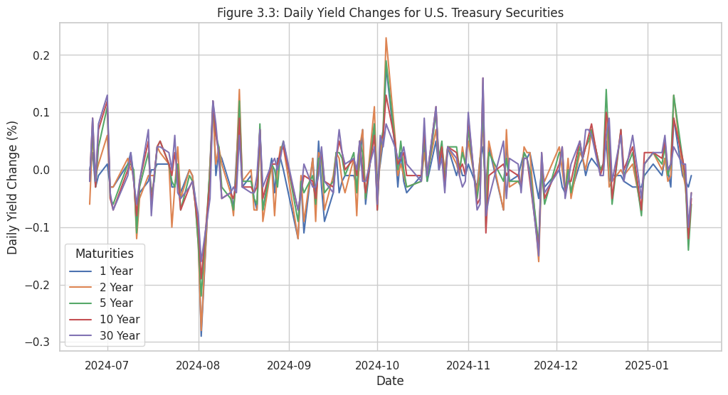

```python
plt.figure(figsize=(12, 6))
for column in daily_yield_changes.columns:
    plt.plot(daily_yield_changes.index, daily_yield_changes[column], label=column)

plt.title('Figure 3.3: Daily Yield Changes for U.S. Treasury Securities')
plt.xlabel('Date')
plt.ylabel('Daily Yield Change (%)')
plt.legend(title="Maturities")
plt.grid(True)
plt.show()
```

g. Re-run the Principal Components using EITHER the correlation or covariance matrix.

**Answer of question g**

Eigenvalues

```python
yields_df_cov = daily_yield_changes.cov()
eigenvalues, eigenvectors = LA.eig(yields_df_cov)
sorted_indices=np.argsort(eigenvalues)[::-1]
eigenvectors=eigenvectors[:,sorted_indices]
eigenvalues=eigenvalues[sorted_indices]
eigenvalues
```

```
array([1.27432534e-02, 1.86871188e-03, 2.76677987e-04, 1.32902058e-04,
       3.25563762e-05])
```

Eigenvectors

```python
eigenvectors
```

```
array([[-0.366009  , -0.535143  , -0.73188899,  0.20908883, -0.01672587],
       [-0.49679164, -0.45651126,  0.40733949, -0.61471393, -0.03157313],
       [-0.50391522,  0.02895065,  0.40052634,  0.62880218,  0.43522153],
       [-0.45748966,  0.36706634,  0.02217696,  0.15266311, -0.79508973],
       [-0.39497866,  0.60798323, -0.37080976, -0.39963788,  0.42087758]])
```

Principal components

```python
principal_components =yields_df.dot(eigenvectors)
principal_components.columns = ["PC_1","PC_2","PC_3","PC_4","PC_5"]
principal_components.dropna(inplace=True)
principal_components.head()
```

| date | PC_1 | PC_2 | PC_3 | PC_4 | PC_5 |
| --- | --- | --- | --- | --- | --- |
| 2024-06-24 | -10.032590 | -0.532780 | -1.633712 | -0.245560 | 0.088697 |
| 2024-06-25 | -9.975655 | -0.525469 | -1.659190 | -0.216314 | 0.089371 |
| 2024-06-26 | -10.128439 | -0.479133 | -1.660047 | -0.225135 | 0.083761 |
| 2024-06-27 | -10.075749 | -0.482554 | -1.647428 | -0.240712 | 0.086957 |
| 2024-06-28 | -10.160836 | -0.406276 | -1.648127 | -0.245083 | 0.082232 |

h. How do the variances of each component compare? In other words, how much variance is explained by Component 1, Component 2, Component 3, etc.?

```python
# Put data into a DataFrame
df_eigval = pd.DataFrame({"Eigenvalues":eigenvalues}, index=range(1,6))

# Work out explained proportion
df_eigval["Explained variance proportion"] = df_eigval["Eigenvalues"] / np.sum(df_eigval["Eigenvalues"])
df_eigval["Cumulative variance proportion"] = df_eigval["Explained variance proportion"].cumsum()
#Format as percentage
df_eigval.style.format({"Explained variance proportion": "{:.2%}",
    "Cumulative variance proportion": "{:.2%}"})
```

|  | Eigenvalues | Explained variance proportion | Cumulative variance proportion |
| --- | --- | --- | --- |
| 1 | 0.012743 | 84.65% | 84.65% |
| 2 | 0.001869 | 12.41% | 97.06% |
| 3 | 0.000277 | 1.84% | 98.90% |
| 4 | 0.000133 | 0.88% | 99.78% |
| 5 | 0.000033 | 0.22% | 100.00% |

i. Produce a screeplot of the variance explained for each component.

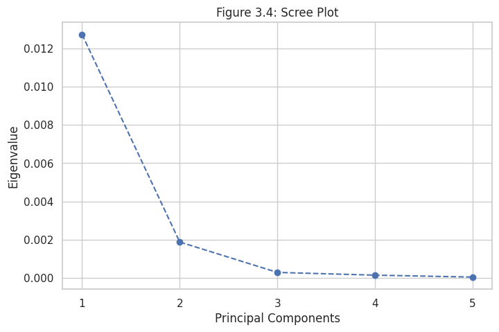

```python
plt.figure(figsize=(8,5))
plt.plot(range(1,len(eigenvalues)+1), eigenvalues,marker="o",linestyle="--")
plt.title("Figure 3.4: Scree Plot")
plt.xlabel("Principal Components")
plt.ylabel("Eigenvalue")
plt.xticks(range(1,len(eigenvalues)+1))
plt.grid(True)
```

j. How does the screeplot from the uncorrelated data compare with the screeplot from the government data?

**Answer**

In the screeplot of uncorrelated data (Figure 3.2), we observe a gradual decline in the dashed line, indicating the need for many principal components to achieve a high proportion of explained variance. Conversely, in the screeplot of government data (Figure 3.4), the dashed line shows a more pronounced decline. This suggests that in correlated data, the first few principal components explain a larger proportion of variability compared to the later components.

## **4. Empirical Analysis of ETFs Pick a sector ETF (in the US, for example, XLRE)**

a. Find the 30 largest holdings.

**Answer**

The 30 largest holdings of XLI Industrials are

```python
keys = ['XLI']
headers = {"User-Agent": "Mozilla/5.0 (Windows NT 10.0; Win64; x64; rv:83.0) Gecko/20100101 Firefox/83.0"}
def main(url):
    with requests.Session() as req:
        req.headers.update(headers)
        for key in keys:
            r = req.get(url.format(key))
            #print(f"Extracting: {r.url}")
            goal = re.findall(r'etf\\\/(.*?)\\', r.text)
            print(goal[:30])
main("https://www.zacks.com/funds/etf/{}/holding")
```

```
['GE', 'CAT', 'RTX', 'HON', 'UNP', 'BA', 'ETN', 'UBER', 'ADP', 'DE', 'LMT', 'UPS', 'GEV', 'TT', 'PH', 'WM', 'TDG', 'EMR', 'MMM', 'ITW', 'GD', 'NOC', 'FDX', 'CTAS', 'CSX', 'CARR', 'PCAR', 'JCI', 'NSC', 'CPRT']
```

b. Get at least 6 months of data (~ 120 data points).

**Answer**

130 recent data points of XLI are

```python
xlf = yfin.download(['GE', 'CAT', 'RTX', 'UBER', 'ETN', 'HON', 'UNP', 'ADP', 'DE', 'BA', 'LMT', 'GEV', 'UPS', 'TT', 'PH', 'WM', 'EMR', 'CTAS', 'ITW', 'TDG', 'MMM', 'GD', 'CSX', 'NOC', 'FDX', 'CARR', 'PCAR', 'NSC', 'URI', 'JCI'])['Close']
xlf.index = pd.to_datetime(xlf.index).strftime("%Y-%m-%d")
xlf=xlf.dropna().iloc[-130:]
xlf
```

```
[*********************100%***********************]  30 of 30 completed
```

| Ticker Date | ADP | BA | CARR | CAT | CSX | CTAS | DE | EMR | ETN | FDX | ... | PCAR | PH | RTX | TDG | TT | UBER | UNP | UPS | URI | WM |
| --- | --- | --- | --- | --- | --- | --- | --- | --- | --- | --- | --- | --- | --- | --- | --- | --- | --- | --- | --- | --- | --- |
| 2024-07-15 | 240.175369 | 179.110001 | 66.957771 | 343.134705 | 34.364563 | 178.026718 | 368.950012 | 115.904816 | 325.018585 | 302.040466 | ... | 101.046936 | 541.951538 | 100.543625 | 1176.302490 | 340.164673 | 72.290001 | 233.394363 | 140.607178 | 704.445190 | 214.500183 |
| 2024-07-16 | 243.323074 | 186.050003 | 69.462715 | 357.831818 | 35.089600 | 180.666565 | 374.747284 | 117.787514 | 330.415192 | 310.457428 | ... | 105.241524 | 565.768982 | 102.581795 | 1212.824585 | 345.471649 | 74.300003 | 240.386597 | 143.709030 | 739.896057 | 219.356216 |
| 2024-07-17 | 246.718231 | 184.839996 | 67.176453 | 355.072998 | 35.208782 | 179.254501 | 382.311493 | 117.173164 | 309.584106 | 307.397614 | ... | 105.550797 | 555.083984 | 103.877922 | 1175.857300 | 334.618286 | 68.620003 | 241.207458 | 143.757812 | 720.557434 | 221.769363 |
| 2024-07-18 | 244.887009 | 180.229996 | 66.649628 | 353.316528 | 34.781704 | 189.014389 | 377.854370 | 115.478729 | 307.169037 | 303.624847 | ... | 106.294998 | 544.866577 | 102.740097 | 1180.072144 | 329.560699 | 66.260002 | 240.337143 | 141.202194 | 725.397095 | 221.550888 |
| 2024-07-19 | 244.461380 | 179.669998 | 65.844460 | 344.980530 | 34.453949 | 188.912292 | 375.293243 | 114.626556 | 309.971710 | 303.317871 | ... | 104.197701 | 541.862000 | 101.721008 | 1172.636963 | 329.331299 | 67.309998 | 239.654755 | 141.611862 | 715.628174 | 221.252960 |
| ... | ... | ... | ... | ... | ... | ... | ... | ... | ... | ... | ... | ... | ... | ... | ... | ... | ... | ... | ... | ... | ... |
| 2025-01-13 | 290.200012 | 170.570007 | 67.110001 | 362.500000 | 31.889999 | 190.600006 | 429.910004 | 118.470001 | 340.880005 | 274.589996 | ... | 108.160004 | 637.989990 | 117.739998 | 1278.459961 | 376.980011 | 65.699997 | 226.759995 | 125.010002 | 689.150024 | 207.529999 |
| 2025-01-14 | 291.690002 | 167.020004 | 68.400002 | 371.570007 | 32.139999 | 192.279999 | 432.309998 | 119.790001 | 340.140015 | 277.619995 | ... | 110.199997 | 647.010010 | 119.470001 | 1300.729980 | 382.709991 | 64.839996 | 229.380005 | 125.839996 | 729.859985 | 207.169998 |
| 2025-01-15 | 293.369995 | 166.199997 | 68.800003 | 374.890015 | 32.459999 | 195.699997 | 428.880005 | 120.720001 | 342.579987 | 276.589996 | ... | 109.629997 | 656.320007 | 119.089996 | 1293.530029 | 385.549988 | 67.019997 | 230.860001 | 127.470001 | 741.489990 | 208.000000 |
| 2025-01-16 | 296.230011 | 168.929993 | 69.739998 | 380.549988 | 32.970001 | 198.050003 | 439.109985 | 123.290001 | 345.190002 | 277.369995 | ... | 109.480003 | 658.659973 | 120.459999 | 1322.020020 | 388.859985 | 68.580002 | 234.889999 | 129.940002 | 757.419983 | 211.009995 |
| 2025-01-17 | 296.179993 | 171.089996 | 69.660004 | 386.019989 | 32.730000 | 198.309998 | 455.440002 | 124.529999 | 346.279999 | 275.100006 | ... | 110.330002 | 669.460022 | 121.110001 | 1340.020020 | 389.190002 | 67.339996 | 234.259995 | 129.729996 | 771.000000 | 211.710007 |

130 rows × 30 columns

c. Compute the daily returns.

**Answer**

The daily returns are

```python
xlf_returns=xlf.dropna().pct_change().dropna()
xlf_returns
```

| Ticker Date | ADP | BA | CARR | CAT | CSX | CTAS | DE | EMR | ETN | FDX | ... | PCAR | PH | RTX | TDG | TT | UBER | UNP | UPS | URI | WM |
| --- | --- | --- | --- | --- | --- | --- | --- | --- | --- | --- | --- | --- | --- | --- | --- | --- | --- | --- | --- | --- | --- |
| 2024-07-16 | 0.013106 | 0.038747 | 0.037411 | 0.042832 | 0.021098 | 0.014828 | 0.015713 | 0.016243 | 0.016604 | 0.027867 | ... | 0.041511 | 0.043948 | 0.020271 | 0.031048 | 0.015601 | 0.027805 | 0.029959 | 0.022060 | 0.050325 | 0.022639 |
| 2024-07-17 | 0.013953 | -0.006504 | -0.032914 | -0.007710 | 0.003397 | -0.007816 | 0.020185 | -0.005216 | -0.063045 | -0.009856 | ... | 0.002939 | -0.018886 | 0.012635 | -0.030480 | -0.031416 | -0.076447 | 0.003415 | 0.000339 | -0.026137 | 0.011001 |
| 2024-07-18 | -0.007422 | -0.024940 | -0.007842 | -0.004947 | -0.012130 | 0.054447 | -0.011658 | -0.014461 | -0.007801 | -0.012273 | ... | 0.007051 | -0.018407 | -0.010953 | 0.003584 | -0.015114 | -0.034392 | -0.003608 | -0.017777 | 0.006717 | -0.000985 |
| 2024-07-19 | -0.001738 | -0.003107 | -0.012081 | -0.023594 | -0.009423 | -0.000540 | -0.006778 | -0.007379 | 0.009124 | -0.001011 | ... | -0.019731 | -0.005514 | -0.009919 | -0.006301 | -0.000696 | 0.015847 | -0.002839 | 0.002901 | -0.013467 | -0.001345 |
| 2024-07-22 | 0.004130 | -0.004286 | 0.026570 | 0.004766 | -0.005189 | 0.017784 | 0.003148 | 0.018586 | 0.027029 | 0.003656 | ... | 0.011595 | 0.013715 | 0.009338 | 0.014361 | 0.021082 | 0.006240 | 0.003920 | 0.000000 | 0.027427 | 0.002917 |
| ... | ... | ... | ... | ... | ... | ... | ... | ... | ... | ... | ... | ... | ... | ... | ... | ... | ... | ... | ... | ... | ... |
| 2025-01-13 | 0.011679 | -0.008314 | 0.009021 | 0.032764 | 0.003461 | 0.006867 | 0.052231 | 0.004494 | -0.001669 | 0.014258 | ... | 0.014825 | 0.012618 | 0.022848 | 0.012954 | -0.000371 | -0.004093 | 0.006882 | 0.014033 | 0.027141 | 0.001351 |
| 2025-01-14 | 0.005134 | -0.020813 | 0.019222 | 0.025021 | 0.007839 | 0.008814 | 0.005583 | 0.011142 | -0.002171 | 0.011035 | ... | 0.018861 | 0.014138 | 0.014693 | 0.017419 | 0.015200 | -0.013090 | 0.011554 | 0.006639 | 0.059073 | -0.001735 |
| 2025-01-15 | 0.005760 | -0.004910 | 0.005848 | 0.008935 | 0.009956 | 0.017787 | -0.007934 | 0.007764 | 0.007173 | -0.003710 | ... | -0.005172 | 0.014389 | -0.003181 | -0.005535 | 0.007421 | 0.033621 | 0.006452 | 0.012953 | 0.015935 | 0.004006 |
| 2025-01-16 | 0.009749 | 0.016426 | 0.013663 | 0.015098 | 0.015712 | 0.012008 | 0.023853 | 0.021289 | 0.007619 | 0.002820 | ... | -0.001368 | 0.003565 | 0.011504 | 0.022025 | 0.008585 | 0.023277 | 0.017456 | 0.019377 | 0.021484 | 0.014471 |
| 2025-01-17 | -0.000169 | 0.012786 | -0.001147 | 0.014374 | -0.007279 | 0.001313 | 0.037189 | 0.010058 | 0.003158 | -0.008184 | ... | 0.007764 | 0.016397 | 0.005396 | 0.013616 | 0.000849 | -0.018081 | -0.002682 | -0.001616 | 0.017929 | 0.003317 |

129 rows × 30 columns

d. Compute the covariance matrix.

**Answer**

The covariance matrix is

```python
xlf_cov_matrix=xlf_returns.cov()
xlf_cov_matrix
```

| Ticker | ADP | BA | CARR | CAT | CSX | CTAS | DE | EMR | ETN | FDX | ... | PCAR | PH | RTX | TDG | TT | UBER | UNP | UPS | URI | WM |
| --- | --- | --- | --- | --- | --- | --- | --- | --- | --- | --- | --- | --- | --- | --- | --- | --- | --- | --- | --- | --- | --- |
| ADP | 0.000095 | 0.000023 | 0.000061 | 0.000074 | 0.000085 | 0.000066 | 0.000048 | 0.000079 | 0.000073 | 0.000050 | ... | 0.000078 | 0.000089 | 0.000061 | 0.000069 | 0.000040 | 0.000019 | 0.000070 | 0.000030 | 0.000098 | 0.000042 |
| BA | 0.000023 | 0.000459 | 0.000100 | 0.000094 | 0.000006 | -0.000025 | 0.000086 | 0.000104 | 0.000119 | 0.000056 | ... | -0.000009 | 0.000104 | 0.000065 | 0.000122 | 0.000053 | 0.000130 | 0.000028 | 0.000026 | 0.000106 | -0.000019 |
| CARR | 0.000061 | 0.000100 | 0.000312 | 0.000167 | 0.000109 | 0.000096 | 0.000098 | 0.000176 | 0.000216 | 0.000095 | ... | 0.000132 | 0.000184 | 0.000062 | 0.000154 | 0.000172 | 0.000160 | 0.000130 | 0.000046 | 0.000231 | 0.000062 |
| CAT | 0.000074 | 0.000094 | 0.000167 | 0.000325 | 0.000150 | 0.000077 | 0.000179 | 0.000226 | 0.000211 | 0.000124 | ... | 0.000185 | 0.000245 | 0.000078 | 0.000126 | 0.000098 | 0.000172 | 0.000125 | 0.000096 | 0.000303 | 0.000014 |
| CSX | 0.000085 | 0.000006 | 0.000109 | 0.000150 | 0.000253 | 0.000088 | 0.000093 | 0.000145 | 0.000103 | 0.000064 | ... | 0.000163 | 0.000167 | 0.000068 | 0.000092 | 0.000047 | 0.000112 | 0.000158 | 0.000081 | 0.000186 | 0.000045 |
| CTAS | 0.000066 | -0.000025 | 0.000096 | 0.000077 | 0.000088 | 0.000269 | 0.000020 | 0.000083 | 0.000109 | 0.000035 | ... | 0.000106 | 0.000100 | 0.000048 | 0.000082 | 0.000087 | 0.000050 | 0.000069 | 0.000049 | 0.000142 | 0.000070 |
| DE | 0.000048 | 0.000086 | 0.000098 | 0.000179 | 0.000093 | 0.000020 | 0.000287 | 0.000106 | 0.000079 | 0.000100 | ... | 0.000123 | 0.000113 | 0.000059 | 0.000020 | 0.000016 | 0.000072 | 0.000077 | 0.000102 | 0.000169 | -0.000004 |
| EMR | 0.000079 | 0.000104 | 0.000176 | 0.000226 | 0.000145 | 0.000083 | 0.000106 | 0.000327 | 0.000215 | 0.000121 | ... | 0.000162 | 0.000239 | 0.000062 | 0.000152 | 0.000126 | 0.000108 | 0.000112 | 0.000087 | 0.000259 | 0.000032 |
| ETN | 0.000073 | 0.000119 | 0.000216 | 0.000211 | 0.000103 | 0.000109 | 0.000079 | 0.000215 | 0.000381 | 0.000089 | ... | 0.000154 | 0.000243 | 0.000044 | 0.000186 | 0.000226 | 0.000220 | 0.000082 | 0.000052 | 0.000269 | 0.000066 |
| FDX | 0.000050 | 0.000056 | 0.000095 | 0.000124 | 0.000064 | 0.000035 | 0.000100 | 0.000121 | 0.000089 | 0.000344 | ... | 0.000104 | 0.000097 | 0.000044 | 0.000035 | 0.000053 | 0.000077 | 0.000093 | 0.000143 | 0.000135 | 0.000038 |
| GD | 0.000071 | 0.000066 | 0.000091 | 0.000099 | 0.000088 | 0.000083 | 0.000047 | 0.000091 | 0.000109 | 0.000030 | ... | 0.000076 | 0.000114 | 0.000104 | 0.000134 | 0.000062 | 0.000066 | 0.000076 | 0.000019 | 0.000138 | 0.000035 |
| GE | 0.000068 | 0.000106 | 0.000183 | 0.000149 | 0.000088 | 0.000078 | 0.000053 | 0.000149 | 0.000246 | 0.000051 | ... | 0.000084 | 0.000186 | 0.000098 | 0.000225 | 0.000193 | 0.000193 | 0.000075 | -0.000014 | 0.000228 | 0.000036 |
| GEV | 0.000076 | 0.000127 | 0.000183 | 0.000227 | 0.000103 | 0.000065 | 0.000068 | 0.000247 | 0.000412 | 0.000099 | ... | 0.000167 | 0.000299 | 0.000064 | 0.000241 | 0.000271 | 0.000216 | 0.000079 | 0.000073 | 0.000285 | 0.000063 |
| HON | 0.000053 | 0.000051 | 0.000104 | 0.000068 | 0.000074 | 0.000056 | 0.000025 | 0.000084 | 0.000095 | 0.000052 | ... | 0.000067 | 0.000075 | 0.000020 | 0.000090 | 0.000072 | 0.000055 | 0.000078 | 0.000026 | 0.000077 | 0.000081 |
| ITW | 0.000059 | 0.000044 | 0.000095 | 0.000121 | 0.000089 | 0.000046 | 0.000088 | 0.000107 | 0.000076 | 0.000081 | ... | 0.000090 | 0.000113 | 0.000054 | 0.000060 | 0.000037 | 0.000061 | 0.000075 | 0.000062 | 0.000135 | 0.000015 |
| JCI | 0.000086 | 0.000056 | 0.000179 | 0.000190 | 0.000125 | 0.000110 | 0.000083 | 0.000191 | 0.000237 | 0.000111 | ... | 0.000163 | 0.000211 | 0.000063 | 0.000158 | 0.000151 | 0.000127 | 0.000110 | 0.000085 | 0.000248 | 0.000063 |
| LMT | 0.000045 | 0.000023 | 0.000026 | 0.000010 | 0.000025 | 0.000030 | 0.000017 | 0.000008 | 0.000003 | -0.000017 | ... | 0.000007 | 0.000031 | 0.000090 | 0.000066 | 0.000035 | -0.000034 | 0.000024 | -0.000047 | 0.000028 | 0.000013 |
| MMM | 0.000070 | 0.000057 | 0.000151 | 0.000161 | 0.000125 | 0.000073 | 0.000082 | 0.000153 | 0.000119 | 0.000067 | ... | 0.000120 | 0.000155 | 0.000059 | 0.000086 | 0.000101 | -0.000022 | 0.000120 | 0.000067 | 0.000155 | 0.000010 |
| NOC | 0.000048 | 0.000017 | 0.000009 | 0.000042 | 0.000054 | 0.000031 | 0.000046 | 0.000034 | 0.000007 | 0.000012 | ... | 0.000028 | 0.000051 | 0.000112 | 0.000057 | 0.000013 | -0.000043 | 0.000031 | 0.000009 | 0.000068 | -0.000019 |
| NSC | 0.000096 | 0.000042 | 0.000130 | 0.000174 | 0.000223 | 0.000112 | 0.000094 | 0.000159 | 0.000124 | 0.000100 | ... | 0.000146 | 0.000161 | 0.000076 | 0.000086 | 0.000061 | 0.000089 | 0.000176 | 0.000099 | 0.000201 | 0.000038 |
| PCAR | 0.000078 | -0.000009 | 0.000132 | 0.000185 | 0.000163 | 0.000106 | 0.000123 | 0.000162 | 0.000154 | 0.000104 | ... | 0.000350 | 0.000170 | 0.000052 | 0.000090 | 0.000082 | 0.000086 | 0.000121 | 0.000168 | 0.000191 | 0.000074 |
| PH | 0.000089 | 0.000104 | 0.000184 | 0.000245 | 0.000167 | 0.000100 | 0.000113 | 0.000239 | 0.000243 | 0.000097 | ... | 0.000170 | 0.000334 | 0.000093 | 0.000159 | 0.000133 | 0.000162 | 0.000126 | 0.000070 | 0.000305 | 0.000029 |
| RTX | 0.000061 | 0.000065 | 0.000062 | 0.000078 | 0.000068 | 0.000048 | 0.000059 | 0.000062 | 0.000044 | 0.000044 | ... | 0.000052 | 0.000093 | 0.000168 | 0.000088 | 0.000038 | -0.000014 | 0.000056 | 0.000010 | 0.000131 | -0.000015 |
| TDG | 0.000069 | 0.000122 | 0.000154 | 0.000126 | 0.000092 | 0.000082 | 0.000020 | 0.000152 | 0.000186 | 0.000035 | ... | 0.000090 | 0.000159 | 0.000088 | 0.000299 | 0.000151 | 0.000160 | 0.000089 | 0.000029 | 0.000186 | 0.000050 |
| TT | 0.000040 | 0.000053 | 0.000172 | 0.000098 | 0.000047 | 0.000087 | 0.000016 | 0.000126 | 0.000226 | 0.000053 | ... | 0.000082 | 0.000133 | 0.000038 | 0.000151 | 0.000221 | 0.000132 | 0.000050 | 0.000018 | 0.000142 | 0.000069 |
| UBER | 0.000019 | 0.000130 | 0.000160 | 0.000172 | 0.000112 | 0.000050 | 0.000072 | 0.000108 | 0.000220 | 0.000077 | ... | 0.000086 | 0.000162 | -0.000014 | 0.000160 | 0.000132 | 0.000739 | 0.000087 | 0.000038 | 0.000187 | 0.000033 |
| UNP | 0.000070 | 0.000028 | 0.000130 | 0.000125 | 0.000158 | 0.000069 | 0.000077 | 0.000112 | 0.000082 | 0.000093 | ... | 0.000121 | 0.000126 | 0.000056 | 0.000089 | 0.000050 | 0.000087 | 0.000172 | 0.000078 | 0.000142 | 0.000051 |
| UPS | 0.000030 | 0.000026 | 0.000046 | 0.000096 | 0.000081 | 0.000049 | 0.000102 | 0.000087 | 0.000052 | 0.000143 | ... | 0.000168 | 0.000070 | 0.000010 | 0.000029 | 0.000018 | 0.000038 | 0.000078 | 0.000286 | 0.000062 | 0.000038 |
| URI | 0.000098 | 0.000106 | 0.000231 | 0.000303 | 0.000186 | 0.000142 | 0.000169 | 0.000259 | 0.000269 | 0.000135 | ... | 0.000191 | 0.000305 | 0.000131 | 0.000186 | 0.000142 | 0.000187 | 0.000142 | 0.000062 | 0.000494 | 0.000018 |
| WM | 0.000042 | -0.000019 | 0.000062 | 0.000014 | 0.000045 | 0.000070 | -0.000004 | 0.000032 | 0.000066 | 0.000038 | ... | 0.000074 | 0.000029 | -0.000015 | 0.000050 | 0.000069 | 0.000033 | 0.000051 | 0.000038 | 0.000018 | 0.000162 |

30 rows × 30 columns

e. Compute the PCA.

**Answer**

The principal component analysis(PCA) is

```python
xlf_returns_mean=xlf_returns.mean()

xlf_returns_std=xlf_returns.std()

xlf_standardized_data=(xlf_returns-xlf_returns_mean)/xlf_returns_std

xlf_standardized_cov=xlf_standardized_data.cov()

eigenvalues, eigenvectors = la.eig(xlf_standardized_cov)
idx = np.argsort(eigenvalues)[::-1]
eigenvalues = eigenvalues[idx]
eigenvectors = eigenvectors[:, idx]

xlf_principal_components= xlf_standardized_data.dot(eigenvectors)
xlf_principal_components.columns=["PC_1","PC_2","PC_3","PC_4","PC_5","PC_6","PC_7","PC_8","PC_9","PC_10","PC_11","PC_12","PC_13","PC_14","PC_15","PC_16","PC_17","PC_18","PC_19","PC_20","PC_21","PC_22","PC_23","PC_24","PC_25","PC_26","PC_27","PC_28","PC_29","PC_30"]
xlf_principal_components
```

| Date | PC_1 | PC_2 | PC_3 | PC_4 | PC_5 | PC_6 | PC_7 | PC_8 | PC_9 | PC_10 | ... | PC_21 | PC_22 | PC_23 | PC_24 | PC_25 | PC_26 | PC_27 | PC_28 | PC_29 | PC_30 |
| --- | --- | --- | --- | --- | --- | --- | --- | --- | --- | --- | --- | --- | --- | --- | --- | --- | --- | --- | --- | --- | --- |
| 2024-07-16 | 7.924030 | 0.137422 | 0.886763 | -0.059148 | 1.805747 | 0.023687 | 0.014664 | 0.273473 | -0.186904 | -0.061284 | ... | 0.500468 | -0.562224 | 0.032079 | -0.623973 | 0.031814 | -0.131576 | -0.058823 | -0.023292 | -0.245373 | -0.536470 |
| 2024-07-17 | -3.543482 | 4.703898 | 3.583108 | -1.650724 | 1.032094 | 0.083364 | 1.125461 | -1.607877 | 0.442119 | 1.205232 | ... | 0.174183 | 0.885378 | -0.356334 | -0.211199 | 0.133578 | -0.097412 | 0.437272 | -0.542359 | 0.474256 | -0.061649 |
| 2024-07-18 | -2.319138 | 0.407285 | -0.737715 | -1.692023 | -0.957578 | -0.698202 | -2.062343 | -0.898443 | -1.145080 | -1.306339 | ... | -0.475764 | -0.436102 | 0.476509 | 0.148484 | 0.000695 | -0.065869 | -0.973560 | 0.277110 | 0.003407 | 0.084452 |
| 2024-07-19 | -2.762167 | -1.247847 | -0.884262 | -0.052278 | -0.624147 | -0.217254 | 0.109672 | 1.256096 | 0.010304 | -0.435093 | ... | -0.365277 | 1.091306 | 0.653740 | 0.187338 | 0.090358 | 0.539398 | -0.171228 | -0.061050 | -0.093868 | 0.545500 |
| 2024-07-22 | 3.317883 | -0.784245 | -1.181744 | -0.277742 | 0.015225 | -0.492282 | -0.304679 | -0.970278 | -0.283205 | -0.771144 | ... | 0.144122 | -0.096397 | -0.115491 | 0.320641 | -0.279635 | 0.171495 | -0.064578 | -0.400981 | -0.228847 | 0.194881 |
| ... | ... | ... | ... | ... | ... | ... | ... | ... | ... | ... | ... | ... | ... | ... | ... | ... | ... | ... | ... | ... | ... |
| 2025-01-13 | 3.924230 | 3.535143 | 1.238639 | 0.974713 | 0.713740 | -1.254833 | 0.087407 | -0.531806 | 1.612548 | -0.358643 | ... | -0.471550 | -0.189333 | -0.098235 | -0.333291 | 0.211624 | 0.395580 | 0.303054 | 0.054771 | -0.147809 | 0.153371 |
| 2025-01-14 | 3.769834 | 0.396798 | -0.001358 | 0.626505 | -1.095203 | -0.868700 | -0.728517 | -0.375547 | 0.356758 | -0.806851 | ... | 0.534097 | -0.694173 | -0.401121 | -0.351800 | -0.730760 | 0.445435 | 0.047243 | -0.352723 | 0.636313 | -0.337180 |
| 2025-01-15 | 1.327423 | -0.907914 | 0.023650 | -0.546966 | 0.050550 | 0.662722 | -0.957914 | 0.446743 | -0.229821 | -0.579190 | ... | 0.876482 | 0.589169 | -0.393185 | -0.431120 | -0.698458 | 0.675571 | 0.231880 | -0.102541 | 0.530894 | 0.146579 |
| 2025-01-16 | 3.884179 | 0.916024 | 0.753182 | -0.524593 | 1.023519 | 0.528138 | 0.448983 | 0.508906 | -0.124216 | 0.053304 | ... | -0.302446 | 0.109677 | 0.272910 | 0.005086 | -0.397692 | 0.076441 | -0.242917 | -0.133467 | -0.007336 | 0.064547 |
| 2025-01-17 | 1.386382 | 0.169151 | -0.446350 | 1.317249 | -0.021273 | -0.813384 | 0.248580 | -0.869154 | 0.785681 | 0.866992 | ... | 0.084466 | -0.051597 | -0.383539 | 0.269699 | 0.253224 | -0.045663 | 0.066251 | -0.244582 | -0.413982 | -0.034901 |

129 rows × 30 columns

f. Compute the SVD.

**Answer**

The singular value decomposition (SVD) is

```python
standardized_returns_dvd_sqrt_n=(xlf_standardized_data/math.sqrt(len(xlf_standardized_data)-1))
U_st_return, s_st_return, VT_st_return = np.linalg.svd(standardized_returns_dvd_sqrt_n)
```

**Matrix of left singular vectors**

```python
U_st_return
```

```
array([[-0.20930198,  0.0074209 , -0.04893938, ..., -0.01761956,
        -0.09612688, -0.01893472],
       [ 0.09359602,  0.25401361, -0.19774751, ..., -0.04017135,
         0.05278976,  0.07862361],
       [ 0.06125673,  0.02199364,  0.04071362, ...,  0.05197161,
         0.06485387, -0.00574327],
       ...,
       [-0.035062  , -0.04902796, -0.00130521, ...,  0.83354267,
        -0.01081503,  0.01220279],
       [-0.10259506,  0.04946591, -0.04156722, ...,  0.00562025,
         0.86803635, -0.00854122],
       [-0.03661932,  0.00913428,  0.02463354, ...,  0.05158599,
        -0.01561285,  0.8748643 ]])
```

**Singular values**

```python
s_st_return
```

```
array([3.34632245, 1.63680109, 1.60156236, 1.36331236, 1.12608502,
       1.06081308, 1.02599675, 0.90912456, 0.86740454, 0.85508141,
       0.82863216, 0.76399463, 0.68735184, 0.67355388, 0.63943669,
       0.61713275, 0.5982534 , 0.58915346, 0.54750511, 0.52876127,
       0.52132406, 0.47621634, 0.47233618, 0.44350506, 0.42235973,
       0.38939778, 0.38502787, 0.3386785 , 0.31066052, 0.25473011])
```

**Eigenvalues With The SVD Method**

```python
s_st_return**2
```

```
array([11.19787397,  2.67911782,  2.565002  ,  1.85862058,  1.26806748,
        1.1253244 ,  1.05266932,  0.82650747,  0.75239063,  0.73116421,
        0.68663126,  0.58368779,  0.47245256,  0.45367483,  0.40887927,
        0.38085283,  0.35790713,  0.3471018 ,  0.29976185,  0.27958848,
        0.27177878,  0.226782  ,  0.22310147,  0.19669673,  0.17838774,
        0.15163063,  0.14824646,  0.11470312,  0.09650996,  0.06488743])
```

**Matrix of the right singular vectors**

```python
VT_st_return.T
```

[output not shown]

[output cut: 245 more lines]

```
        -1.95043407e-01,  9.41344431e-02, -8.96160809e-02,
        -1.93669312e-01, -2.77182941e-01,  2.03192740e-01,
         2.13718784e-01, -2.73290112e-01,  2.93250785e-03,
         2.54605909e-01,  4.05348423e-01,  1.20116917e-01,
         2.95004917e-01, -2.07038143e-01, -8.16965520e-02],
       [-9.26843088e-02, -1.43711414e-01,  1.02962326e-02,
         5.32817020e-01, -1.88515754e-01,  1.36900630e-01,
        -1.00193790e-01,  1.64064697e-02,  1.67420857e-01,
        -1.32579642e-01,  4.96911897e-02,  2.64892788e-01,
        -3.58782210e-02, -2.51912216e-01,  1.14511692e-01,
        -1.30576792e-01, -2.61789839e-02, -4.92368779e-01,
        -5.76320838e-02, -2.80122198e-01,  2.06965217e-01,
        -1.19696792e-01, -5.69479674e-02, -2.40639658e-02,
         2.77121618e-02, -4.37756691e-02, -8.46245379e-02,
        -4.64828950e-02,  8.81483650e-02, -5.78901592e-02]])
```

**The percentage of variance contribution each principal component catches.**

```python
df_eigval = pd.DataFrame({"Eigenvalues":eigenvalues}, index=range(1,31))
df_eigval["Explained proportion"] = df_eigval["Eigenvalues"] / np.sum(df_eigval["Eigenvalues"])
df_eigval["Explained proportion"]=df_eigval["Explained proportion"].map('{:.2%}'.format)

df_eigval
```

|  | Eigenvalues | Explained proportion |
| --- | --- | --- |
| 1 | 11.197874 | 37.33% |
| 2 | 2.679118 | 8.93% |
| 3 | 2.565002 | 8.55% |
| 4 | 1.858621 | 6.20% |
| 5 | 1.268067 | 4.23% |
| 6 | 1.125324 | 3.75% |
| 7 | 1.052669 | 3.51% |
| 8 | 0.826507 | 2.76% |
| 9 | 0.752391 | 2.51% |
| 10 | 0.731164 | 2.44% |
| 11 | 0.686631 | 2.29% |
| 12 | 0.583688 | 1.95% |
| 13 | 0.472453 | 1.57% |
| 14 | 0.453675 | 1.51% |
| 15 | 0.408879 | 1.36% |
| 16 | 0.380853 | 1.27% |
| 17 | 0.357907 | 1.19% |
| 18 | 0.347102 | 1.16% |
| 19 | 0.299762 | 1.00% |
| 20 | 0.279588 | 0.93% |
| 21 | 0.271779 | 0.91% |
| 22 | 0.226782 | 0.76% |
| 23 | 0.223101 | 0.74% |
| 24 | 0.196697 | 0.66% |
| 25 | 0.178388 | 0.59% |
| 26 | 0.151631 | 0.51% |
| 27 | 0.148246 | 0.49% |
| 28 | 0.114703 | 0.38% |
| 29 | 0.096510 | 0.32% |
| 30 | 0.064887 | 0.22% |

Now that you have calculated, presented and plotted tasks from c to f, you must explain each transformation thoroughly. Write a paragraph of 500 words at minimum that explains why returns are important, compare and contrast PCA and SVD, explain what the eigenvectors, eigenvalues, singular values etc show us for the specific data, etc.

**Answer**

Returns are a measure of the performance of our investments and allow us to compare performances from different investments. PCA is primarily used for dimensionality reduction, while SVD has broader applications, including matrix approximation and dimensionality reduction (Hair 92). Both PCA and SVD produce orthogonal vectors and the same eigenvalues. PCA involves computing eigenvectors and eigenvalues of the covariance matrix, while SVD directly deals with singular values. The singular values obtained from SVD can be used to calculate a variance of each principal component (Schwarz et al 2256). Each eigenvector transforms the standardized dataset into a principal component, whichcan explain a portion of the variance of the dataset. The corresponding eigenvalue for the principal component is the variance of the whole data explained by the principal component. The sum of all the eigenvalues is the total variance of the data.

## **Conclusion**

Ensuring data quality in financial analysis is of paramount importance. Poor-quality data, whether structured or unstructured, hampers accurate modeling and reliable decision-making. For instance, in the context of this assignment, structured data included currency symbols, placeholders, and improper classifications that hinder numerical operations. Similarly, unstructured data exhibited missing values and formatting issues that complicated assessment.

The comparative analysis of the Nelson-Siegel and Cubic-Spline models highlighted their respective strengths and weaknesses. The Nelson-Siegel model, while easier to interpret, struggled with certain maturities, whereas the Cubic-Spline model offered a more precise fit but lacked clear economic interpretation. Ethical considerations in data smoothing were addressed, emphasizing transparency and accuracy over potential misrepresentation.

Principal Component Analysis (PCA) and Singular Value Decomposition (SVD) both proved essential in reducing dimensionality and understanding underlying data structures, offering insights into returns and variability in investment performance. The screeplots revealed the differences in explained variance between uncorrelated and government data, emphasizing the significance of correlation in principal components.

## **References**

Akinyemi, Kemi, et al. ''Yield curve extrapolation methods: Methodologies for valuing cash flows that extend beyond the maximum yield curve''. *Society of actuaries*, March (2019), https://www.soa.org/resources/research-reports/2019/yield-curve-report/

Copeland, Ronald M. "Income smoothing." *Journal of accounting research*, (1968): 101-116, https://doi.org/10.2307/2490073

Hair, J. F., et al. *Multivariate Data Analysis.* 7th Edn Prentice Hall International. Prentice Hall, (2009).

Huh, Y. U., et al. ''Data quality''. *Information and software technology*, 32.8 (1990): 559-565., https://www.sciencedirect.com/science/article/pii/095058499090146I

Liu, Grace. "Data quality problems troubling business and financial researchers: A literature review and synthetic analysis." *Journal of Business & Finance Librarianship*, 25.3-4 (2020): 315-371, https://doi.org/10.1080/08963568.2020.1847555

Nadinić, Berislav, and Damir Kalpić. "Data quality in finances and its impact on credit risk management and CRM integration." *International Conference on Software and Data Technologies, Special Session on Applications in Banking and Financing*, (3; 2008). 2008, https://doi.org/10.5220/0001879103270331

Nymand-Andersen, Per. ''Yield curve modelling and a conceptual framework for estimating yield curves: evidence from the European Central Bank's yield curves''. *ECB Statistics Paper*, 27, 2018, https://doi.org/10.2866/892636

Praveen, Shagufta, and Umesh Chandra. "Influence of structured, semi-structured, unstructured data on various data models." *International Journal of Scientific & Engineering Research*, 8.12 (2017): 67-69, https://www.researchgate.net/publication/344363081

Schwarz, Christian, et al. "Principal component analysis and singular value decomposition used for a numerical sensitivity analysis of a complex drawn part." *The International Journal of Advanced Manufacturing Technology*, 94 (2018): 2255-2265. https://link.springer.com/article/10.1007/s00170-017-0980-z

Sebastian-Coleman, Laura. *Measuring data quality for ongoing improvement: a data quality assessment framework*. Newnes, 2012, https://www.sciencedirect.com/book/9780123970336/measuring-data-quality-for-ongoing-improvement

Strong, Diane M., et al. "Data quality in context." *Communications of the ACM*, 40.5 (1997): 103-110, https://doi.org/10.1145/253769.253804

Wahlstrøm, Ranik Raaen, et al. ''A comparative analysis of parsimonious yield curve models with focus on the Nelson-Siegel, Svensson and Bliss versions''. *Computational Economics* (2022): 1-38, https://doi.org/10.1007/s10614-021-10113-w

Wang, Richard Y., and Diane M. Strong. "Beyond accuracy: What data quality means to data consumers." *Journal of management information systems*, 12.4 (1996): 5-33, https://doi.org/10.1080/07421222.1996.11518099.

**Useful links**

[Data Society](https://www.kaggle.com/datasets/thedevastator/airplane-crashes-and-fatalities/data)

[Atharva Arya](https://www.kaggle.com/datasets/atharvaarya25/financials)

.

```python
%%capture
!wget -nc https://raw.githubusercontent.com/brpy/colab-pdf/master/colab_pdf.py
from colab_pdf import colab_pdf
colab_pdf('Group_Work_Project 1, group 8072.ipynb')
#set_matplotlib_formats('pdf', 'svg')
```